# Blog del curso “Escribiendo con R y Quarto”

Este “blog” es un recurso más dentro del curso.

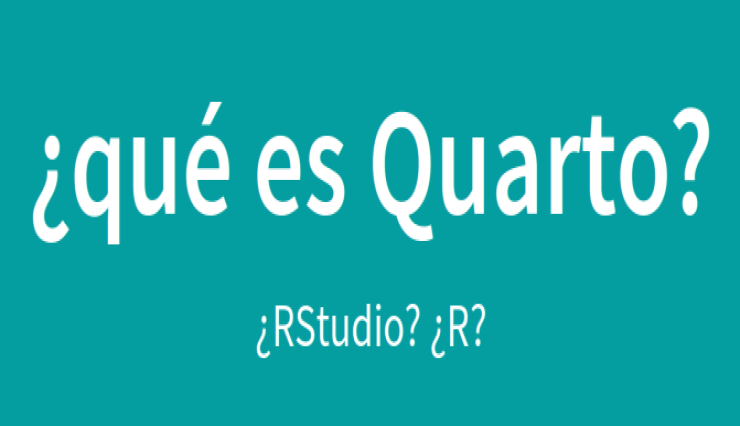

### ¿Qué son R, RStudio y Quarto?

reproducibilidad

En el curso usaremos 3 programas: R, RStudio y Quarto, así que la primera tarea es saber qué son y para qué sirven: conviene saber diferenciar entre ellos.

2 ene 2023

Pedro J. Pérez

7 minutos

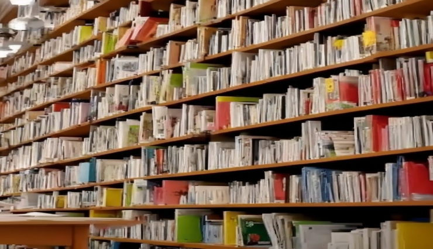

### Referencias bibliográficas

Quarto

bibliografía

¿Cómo incluir referencias bibliográficas en documentos `.qmd`? Una buena opción es a través de ficheros `.bib` creados en Zotero.

20 ene 2023

Pedro J. Pérez

9 minutos

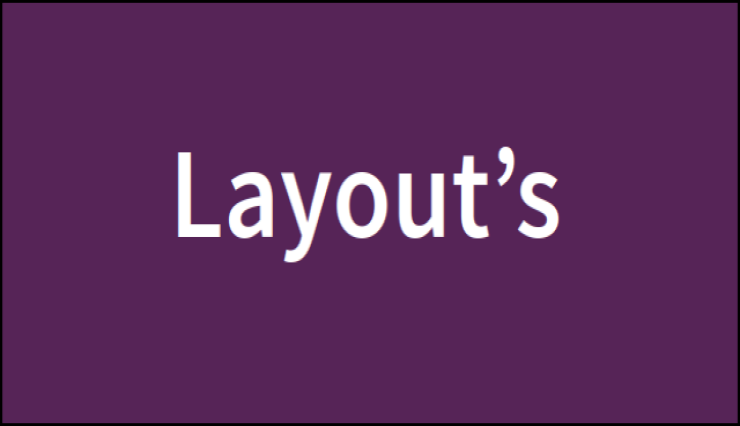

### Layout’s

Quarto

layout

Viendo las posibilidades de Layout que tenemos en Quarto

21 ene 2023

Pedro J. Pérez

2 minutos

[figure not shown]

### Usando shortcodes

Quarto

shortcodes

Cómo usar *shortcodes* en Quarto para, entre otras cosas, poder incluir el mismo contenido en varios documentos.

22 ene 2023

Pedro J. Pérez

6 minutos

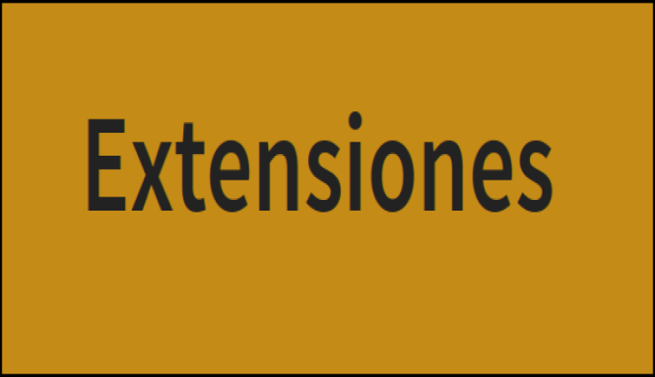

### Extensiones

Quarto

extensiones

Intentando entender qué son y cómo usar las extensiones de Quarto

23 ene 2023

Pedro J. Pérez

2 minutos

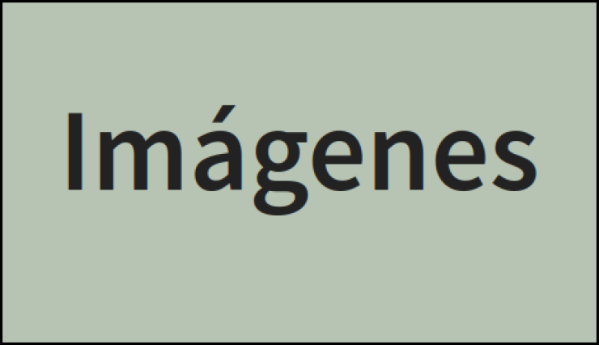

### Imágenes

Quarto

imágenes

Repasando algunas opciones de Quarto para insertar imágenes.

24 ene 2023

Pedro J. Pérez

2 minutos

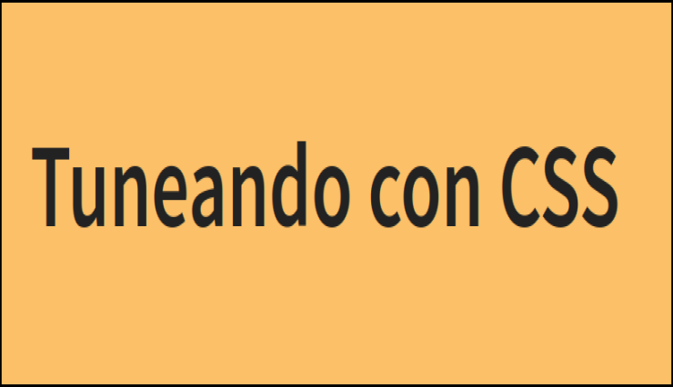

### Tuneando con CSS

Quarto

CSS

Cambiando el formato con CSS

25 ene 2023

Pedro J. Pérez

5 minutos

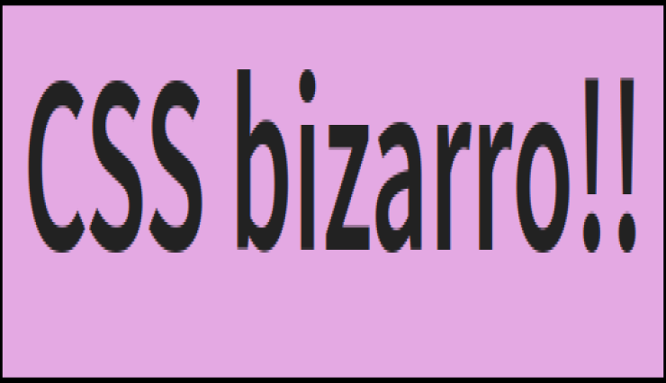

### Tuneando con CSS (cambios bizarros!!)

Quarto

CSS

El contenido de este post es el mismo que el del anterior, **PERO** , pero ahora haciendo cambios **bizarros!!** con CSS.

26 ene 2023

Pedro J. Pérez

5 minutos

[figure not shown]

### Observable JS

Quarto

Observable

Intentando entender qué es y cómo usar **Observable JS** en R.

27 ene 2023

Pedro J. Pérez

4 minutos

[figure not shown]

### Using R data with phyton

Quarto

Python

Viendo cómo usar datos de R en chunks de Py con Quarto.

28 ene 2023

Pedro J. Pérez

1 minutos

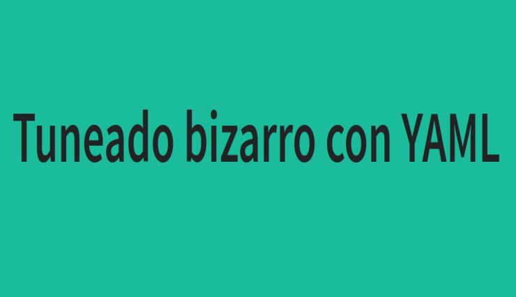

### Tuneado de un post con opciones de YAML

Quarto

tuneado yaml

Viendo cómo modificar la apariencia de un post con opciones de YAML.

29 ene 2023

Pedro J. Pérez

1 minutos

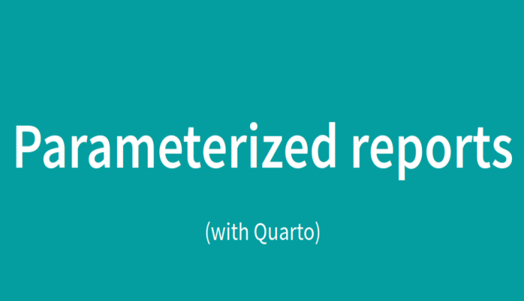

### Informes parametrizados

reproducibilidad

Informes parametrizados

Automatizando la creación de informes: generando grupos de informes utilizando conjuntos de parámetros.

30 ene 2023

Pedro J. Pérez

4 minutos

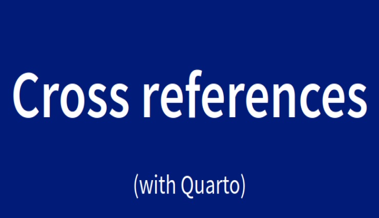

### Cross references

reproducibilidad

Informes parametrizados

¿Cómo insertar referencias cruzadas en documentos Quarto?

31 ene 2023

Pedro J. Pérez

5 minutos

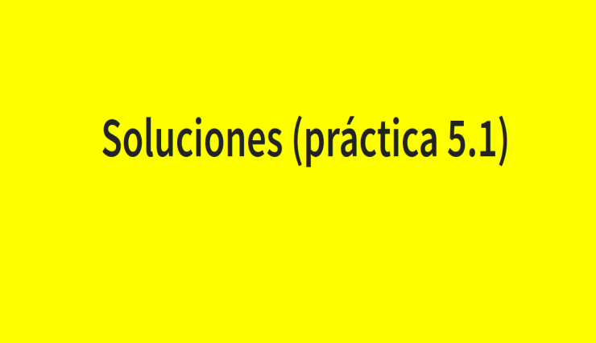

### Mi Segundo post con Quarto

Taller

soluciones practica nº 5

Soluciones a la Práctica 5.1 del curso

1 feb 2023

Nosotros

1 minutos

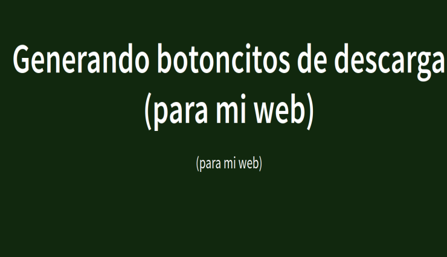

### Generando botoncitos de descarga en mi web

Tuneando la web

Insertar un link de descarga en nuestra web es muy fácil pero quedará más chulo si generamos unos botoncitos de descarga.

2 feb 2023

Pedro J. Pérez

4 minutos

### Generando tablas con R

tablas

Se pueden hacer tablas muy chulas con R. Por ejemplo mira aquí

3 feb 2023

Pedro J. Pérez

5 minutos

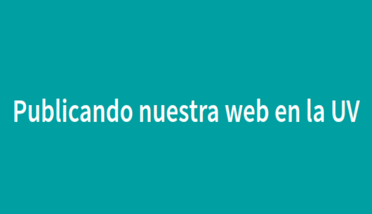

### Publicando nuestra web en la UV

Quarto

Publicando la web

Se describe el proceso para publicar nuestra web/blog en el espacio web que tenemos disponible en los servidores de la Universitat de València.

4 feb 2023

Pedro J. Pérez

3 minutos

### Generando tablas de modelos y contrastes

tablas estadísticas

Post en proceso de elaboración

5 feb 2023

Pedro J. Pérez

1 minutos

### Algunos trucos CSS y SASS

CSS

SASS

Post en proceso de elaboración

6 feb 2023

Pedro J. Pérez

1 minutos

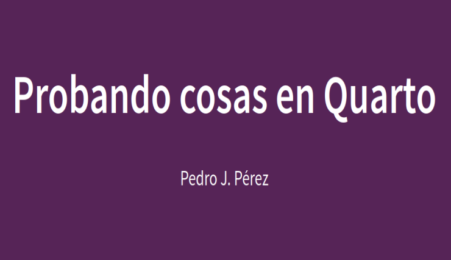

### Recopilando truquillos

Quarto

pruebas

Post fake para ir recopilando los truquillos que me van surgiendo

9 sept 2023

Pedro J. Pérez

6 minutos